# Dungeons and Dragons, Stats for 6/18/2015

dyg

2015-06-21 22:46:43

So me and my friends play Dungeons and Dragons every week. A few weeks in we decided it would be a good idea to start recording our d20 rolls. This came from one of my friends being declared as highly bimodel in his rolls, i.e. he rolls close to a 1 or a 20. I’m no fan of confirmation bias, and having a love for stats, R and data graphics I thought this would be a fun analysis. I will most likely post these types of analyses every week or so depending on how busy I am.

## A look at the dataset

```r
#all the states are kept in a google docs sheet, which can be downloaded as a
#csv
df <- read.csv("Roll_Stats_06212015.csv", header = T, sep = ",")

#first look
str(df)
```

```
## 'data.frame':    488 obs. of  4 variables:
##  $ Person    : Factor w/ 10 levels "jeff","Jeff",..: 2 2 2 2 2 2 2 2 7 7 ...
##  $ Die       : Factor w/ 1 level "d20": 1 1 1 1 1 1 1 1 1 1 ...
##  $ Roll_Value: int  1 16 5 5 15 13 2 15 1 3 ...
##  $ Date      : Factor w/ 7 levels "5/14/2015","5/20/2015",..: 4 4 4 4 4 4 4 4 4 4 ...
```

Ah, a few considerations before we begin plotting away. First the Person variable needs to be cleaned up, I know for a fact that we have 4 players, but R is listing 10 uniques. To me this means there are probably some typos or leading and trailing spaces. Secondly, the Date variable isn’t a date. This should do it:

```r
#load some libs
library(stringr)
library(dplyr)

#Now do the cleaning
df$Person <- df$Person %>%
  tolower() %>%
    str_trim() %>%
      as.factor()

df$Date <- as.Date(as.character(df$Date), format = "%m/%d/%Y")

#have a quick look at the cleaned dataset
str(df)
```

```
## 'data.frame':    488 obs. of  4 variables:
##  $ Person    : Factor w/ 4 levels "jeff","mel","mike",..: 1 1 1 1 1 1 1 1 3 3 ...
##  $ Die       : Factor w/ 1 level "d20": 1 1 1 1 1 1 1 1 1 1 ...
##  $ Roll_Value: int  1 16 5 5 15 13 2 15 1 3 ...
##  $ Date      : Date, format: "2015-05-07" "2015-05-07" ...
```

Perfect. First I want see how many total rolls have happened, and how many weeks we have been recording data:

```r
#Observe that each row is a roll
head(df)
```

```
##   Person Die Roll_Value       Date
## 1   jeff d20          1 2015-05-07
## 2   jeff d20         16 2015-05-07
## 3   jeff d20          5 2015-05-07
## 4   jeff d20          5 2015-05-07
## 5   jeff d20         15 2015-05-07
## 6   jeff d20         13 2015-05-07
```

```r
#now what are the dimensions of the dataset
length(df$Roll_Value)
```

```
## [1] 488
```

Now how many rolls has everyone made to date, by date, and what were they, specifically?

```r
#Total rolls by Person
table(df$Person)
```

```
##
## jeff  mel mike will
##  141   86  152  109
```

```r
#Rolls by person/date
table(df$Date, df$Person)
```

```
##
##              jeff mel mike will
##   2015-05-07    8   5   22   10
##   2015-05-14   18  18   21   11
##   2015-05-20   25  12   29   23
##   2015-05-28   30   7   34   24
##   2015-06-04   27  22   10   18
##   2015-06-12   18  12   25   11
##   2015-06-18   15  10   11   12
```

```r
#Roll count by Person and Roll
table(df$Roll_Value, df$Person)
```

```
##
##      jeff mel mike will
##   1    12   9   14    6
##   2     7   1   12    5
##   3    12   4    3    4
##   4     4   4    6    6
##   5    12   1    3    4
##   6     4   5    5    5
##   7     3   6   11    1
##   8     5   2    5    5
##   9     8   4    9    8
##   10    4   4    4    2
##   11    5   4    9    5
##   12    6   4   15   11
##   13    9   1    3    6
##   14    7   7    7    4
##   15    8   4    5    7
##   16   10   5    7    5
##   17    6   4    8    8
##   18    6   7    9    7
##   19   10   3   12    6
##   20    3   7    5    4
```

Thats nice but its really just for someone who wants detail that a plot isn’t going to provide. A few things of note, me (Jeff) have rolled the second most one’s after mike. I would expect this data to be affected by play style, class, and most importantly luck. A quick note, the player “mel” is a halfling who has the feat “lucky”. Basically, whenever she rolls a nat 1 she can re-roll. Being the data scribe in the group my practice has been to record both d20 rolls.

## Pretty Graphics

Ok now on to the fun stuff. I want to see each players total distributions, and how each players roll behavior has changed each week.

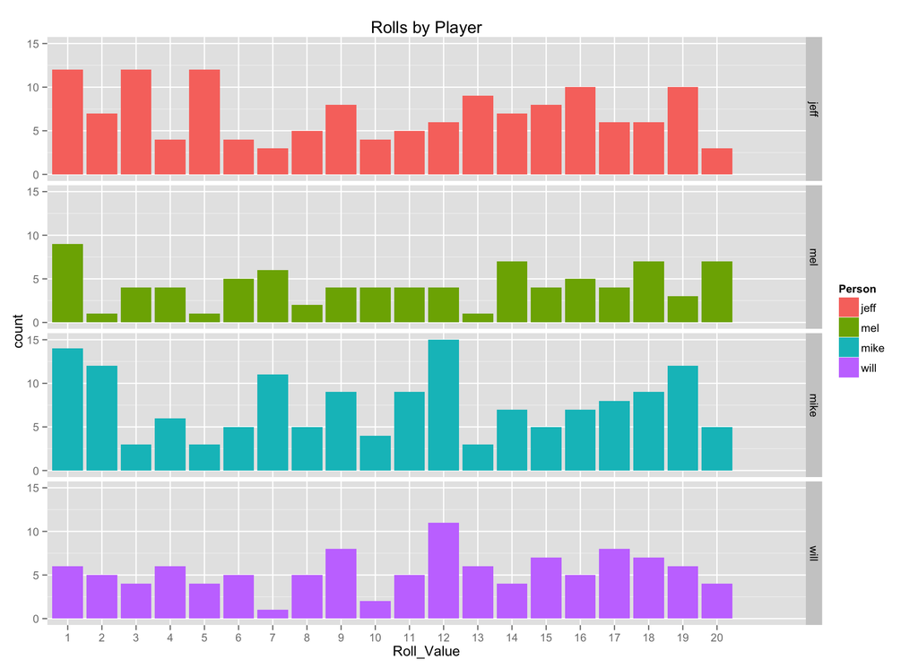

```r
#load ggplot
library(ggplot2)

#Make histrograms faceted by person
ggplot(data = df, aes(x = Roll_Value, fill = Person)) +
  geom_histogram(stat = "bin") +
  facet_grid(Person ~ .) +
  ggtitle("Rolls by Player") +
  scale_x_discrete(breaks = seq(1, 20))
```

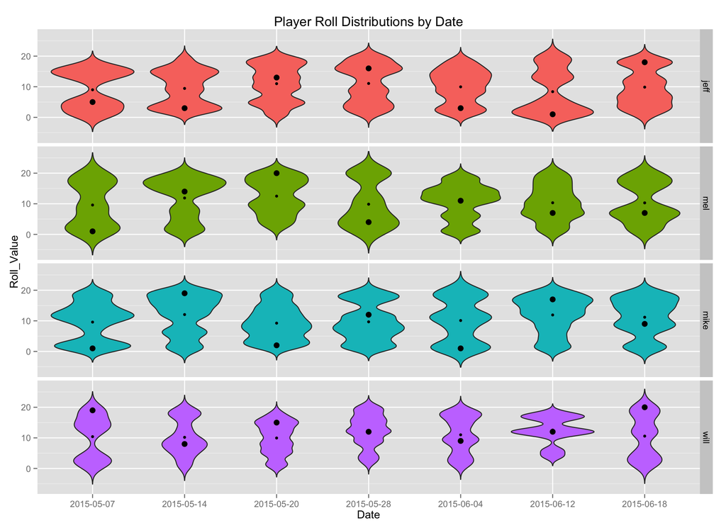

```r
#load dplyr
library(dplyr)

#do some statistics
simpleStat <- function(fun, geom="point", ...) {
  stat_summary(fun.y = fun, geom=geom, ...)
}

myQuantile <- function(x) {
  out <- quantile(x, probs = c(0.25, 0.75))
  out
}

myMode <- function(x) {
  ux <- unique(x)
  ux[which.max(tabulate(match(x, ux)))]
}

#now generate plot
ggplot(df, aes(x = factor(Date), y = Roll_Value, fill = Person)) +
  xlab("Date") +
  geom_violin(trim = FALSE, adjust = 0.5) +
  simpleStat(myMode, size = 3) +
  simpleStat(mean, size = 1.5) +
  facet_grid(Person ~ .) +
  theme(legend.position = "none") +
  ggtitle("Player Roll Distributions by Date")
```

The plot is a violin plot for each week of data given (for more on Violin Plots go [here][1]), the large dot in each violin plot is the mode of that players rolls for that week, the smaller dot is the mean of that players rolls for that week. Subjectively, mode seems to be a better indicator of how well I percieve I roll in a given week. For instance, I remember think “I rolled like complete crap today”, two weeks ago on 6/12. The mode displays this more clearly than the mean.

Lastly I want a line plot to literally connect the dots over each week for each player:

```r
#generate summary dataset
df.change <- df %>%
  group_by(Date, Person) %>%
    summarise(personMean = mean(Roll_Value, na.rm = TRUE),
              personMode = myMode(Roll_Value))

#check the new dataset
head(df.change)
```

```
## Source: local data frame [6 x 4]
## Groups: Date
##
##         Date Person personMean personMode
## 1 2015-05-07   jeff   9.000000          5
## 2 2015-05-07    mel   9.600000          1
## 3 2015-05-07   mike   9.590909          1
## 4 2015-05-07   will  10.400000         19
## 5 2015-05-14   jeff   9.444444          3
## 6 2015-05-14    mel  11.888889         14
```

```r
#great now lets melt it with tidyr
library(tidyr)
df.tidy <- df.change %>%
  gather(stat, value, -Person, -Date)

#again, a quick look
head(df.tidy)
```

```
## Source: local data frame [6 x 4]
##
##         Date Person       stat     value
## 1 2015-05-07   jeff personMean  9.000000
## 2 2015-05-07    mel personMean  9.600000
## 3 2015-05-07   mike personMean  9.590909
## 4 2015-05-07   will personMean 10.400000
## 5 2015-05-14   jeff personMean  9.444444
## 6 2015-05-14    mel personMean 11.888889
```

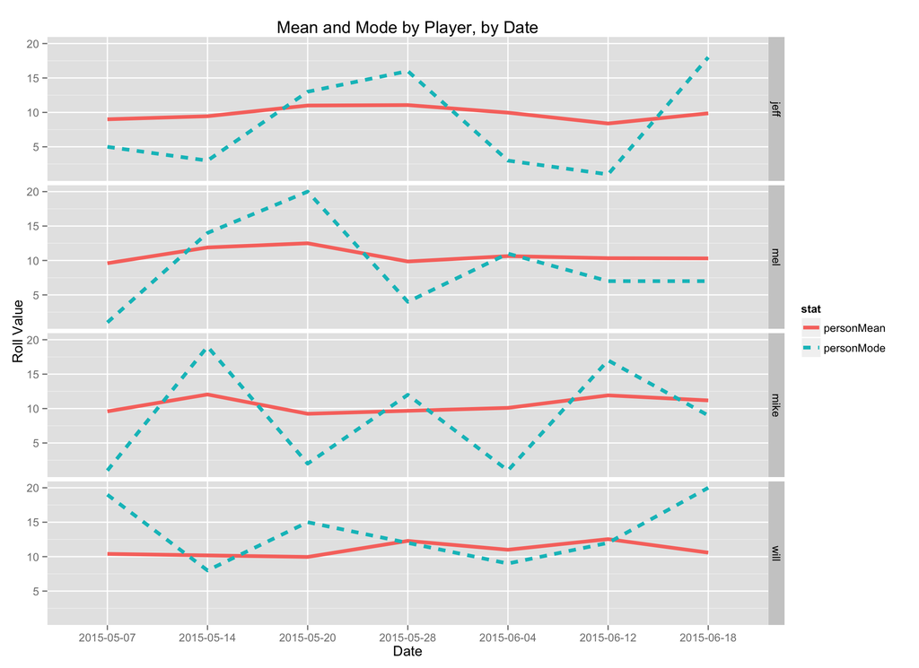

```r
#plot time series
ggplot(df.tidy, aes(x = factor(Date), y = value, group = stat,
                    color = stat)) +
  geom_line(aes(linetype = stat), size = 1.5) +
  facet_grid(Person ~ .) +
  ggtitle("Mean and Mode by Player, by Date") +
  ylab("Roll Value") +
  xlab("Date")
```

## Conclusions

My friend Will thinks he encounters low rolls every three weeks. Well that is objectively not true according to this dataset. However Will is the most consistent player. Looking at his mean and mode he shows the least variation of anyone. One interesting detail is that Mike is decidedly bimodal, is mode oscillates almost perfectly on a two week basis. Not only this but he has rolled the most 1’s, and the second most 20’s.